# Logistic regression with TEDS_2016

Dasha Djukic-Min

4/5/2022

#### Use the TEDS2016 dataset to run a logit (logistic regression) model using female as sole predictor. The dependent variable is the vote (1-0) for Tsai Ing-wen, the female candidate for the then opposition party Democratic Progressive Party (DPP). Access the data set using the following codes:

```r
library(haven)
TEDS_2016<-read_stata("https://github.com/datageneration/home/blob/master/DataProgramming/data/TEDS_2016.dta?raw=true")
```

#### Check the dataset

```r
names(TEDS_2016)
```

```
##  [1] "District"        "Sex"             "Age"             "Edu"
##  [5] "Arear"           "Career"          "Career8"         "Ethnic"
##  [9] "Party"           "PartyID"         "Tondu"           "Tondu3"
## [13] "nI2"             "votetsai"        "green"           "votetsai_nm"
## [17] "votetsai_all"    "Independence"    "Unification"     "sq"
## [21] "Taiwanese"       "edu"             "female"          "whitecollar"
## [25] "lowincome"       "income"          "income_nm"       "age"
## [29] "KMT"             "DPP"             "npp"             "noparty"
## [33] "pfp"             "South"           "north"           "Minnan_father"
## [37] "Mainland_father" "Econ_worse"      "Inequality"      "inequality5"
## [41] "econworse5"      "Govt_for_public" "pubwelf5"        "Govt_dont_care"
## [45] "highincome"      "votekmt"         "votekmt_nm"      "Blue"
## [49] "Green"           "No_Party"        "voteblue"        "voteblue_nm"
## [53] "votedpp_1"       "votekmt_1"
```

#### Logistic regression

```r
 teds.fit=glm(votetsai~female, data=TEDS_2016,family=binomial)
summary(teds.fit)
```

```
##
## Call:
## glm(formula = votetsai ~ female, family = binomial, data = TEDS_2016)
##
## Deviance Residuals:
##     Min       1Q   Median       3Q      Max
## -1.4180  -1.3889   0.9546   0.9797   0.9797
##
## Coefficients:
##             Estimate Std. Error z value Pr(>|z|)
## (Intercept)  0.54971    0.08245   6.667 2.61e-11 ***
## female      -0.06517    0.11644  -0.560    0.576
## ---
## Signif. codes:  0 '***' 0.001 '**' 0.01 '*' 0.05 '.' 0.1 ' ' 1
##
## (Dispersion parameter for binomial family taken to be 1)
##
##     Null deviance: 1666.5  on 1260  degrees of freedom
## Residual deviance: 1666.2  on 1259  degrees of freedom
##   (429 observations deleted due to missingness)
## AIC: 1670.2
##
## Number of Fisher Scoring iterations: 4
```

#### Female voters are not more likely to vote for President Tsai becasue the coefficient for “female” (-0.06) is negative and it is not statistically significant.

#### Improve the model by adding party ID variables (KMT, DPP) and other demographic variables (age, edu, income)

```r
teds.fit2=glm(votetsai~female+KMT+DPP+Age+edu+income,
                data=TEDS_2016,family=binomial)
summary(teds.fit2)
```

```
##
## Call:
## glm(formula = votetsai ~ female + KMT + DPP + Age + edu + income,
##     family = binomial, data = TEDS_2016)
##
## Deviance Residuals:
##     Min       1Q   Median       3Q      Max
## -2.7416  -0.3658   0.2370   0.3098   2.5712
##
## Coefficients:
##             Estimate Std. Error z value Pr(>|z|)
## (Intercept)  1.73673    0.50898   3.412 0.000644 ***
## female       0.04276    0.17769   0.241 0.809828
## KMT         -3.14616    0.25036 -12.567  < 2e-16 ***
## DPP          2.90604    0.26860  10.819  < 2e-16 ***
## Age         -0.18582    0.08132  -2.285 0.022307 *
## edu         -0.21355    0.08135  -2.625 0.008660 **
## income       0.01534    0.03447   0.445 0.656222
## ---
## Signif. codes:  0 '***' 0.001 '**' 0.01 '*' 0.05 '.' 0.1 ' ' 1
##
## (Dispersion parameter for binomial family taken to be 1)
##
##     Null deviance: 1661.76  on 1256  degrees of freedom
## Residual deviance:  833.61  on 1250  degrees of freedom
##   (433 observations deleted due to missingness)
## AIC: 847.61
##
## Number of Fisher Scoring iterations: 6
```

#### I find that “female” is now positively correlated with the DV, although the variable is still not statistically significant. “KMT”, “DPP”, “Age” and “edu” are all statistically significant. It appears that KMT party followers are less likely to vote for Tsai Ing-wen, whereas DPP party members are more likely to do so. Age and education are negatively related to the DV, implying that those that are younger and less educated are more likely to vote for Tsai Ing-wen.

#### Add more variables to further improve the model

```r
teds.fit3=glm(votetsai~female+KMT+DPP+Age+edu+income+Independence+Econ_worse+Govt_dont_care+Minnan_father+Mainland_father+Taiwanese,
                 data=TEDS_2016,family=binomial)
summary(teds.fit3)
```

```
##
## Call:
## glm(formula = votetsai ~ female + KMT + DPP + Age + edu + income +
##     Independence + Econ_worse + Govt_dont_care + Minnan_father +
##     Mainland_father + Taiwanese, family = binomial, data = TEDS_2016)
##
## Deviance Residuals:
##     Min       1Q   Median       3Q      Max
## -3.0923  -0.3137   0.1752   0.4018   2.7948
##
## Coefficients:
##                 Estimate Std. Error z value Pr(>|z|)
## (Intercept)      0.30622    0.58758   0.521  0.60226
## female          -0.09986    0.18979  -0.526  0.59878
## KMT             -2.91362    0.25916 -11.243  < 2e-16 ***
## DPP              2.47566    0.27566   8.981  < 2e-16 ***
## Age             -0.01681    0.08932  -0.188  0.85075
## edu             -0.12769    0.08846  -1.444  0.14887
## income           0.02281    0.03643   0.626  0.53127
## Independence     0.99884    0.25097   3.980 6.89e-05 ***
## Econ_worse       0.31991    0.19007   1.683  0.09236 .
## Govt_dont_care  -0.02141    0.18852  -0.114  0.90960
## Minnan_father   -0.23182    0.25413  -0.912  0.36166
## Mainland_father -1.04536    0.39853  -2.623  0.00872 **
## Taiwanese        0.89430    0.19939   4.485 7.28e-06 ***
## ---
## Signif. codes:  0 '***' 0.001 '**' 0.01 '*' 0.05 '.' 0.1 ' ' 1
##
## (Dispersion parameter for binomial family taken to be 1)
##
##     Null deviance: 1661.76  on 1256  degrees of freedom
## Residual deviance:  767.27  on 1244  degrees of freedom
##   (433 observations deleted due to missingness)
## AIC: 793.27
##
## Number of Fisher Scoring iterations: 6
```

# Logistic regression in STATA

#### Load the dataset

use “https://github.com/datageneration/home/blob/master/DataProgramming/data/TEDS_2016.dta?raw=true”

#### Logistic regression

logit votetsai Independence Econ_worse Govt_dont_care Minnan_father Mainland_father Taiwanese KMT DPP age edu female

#### Output

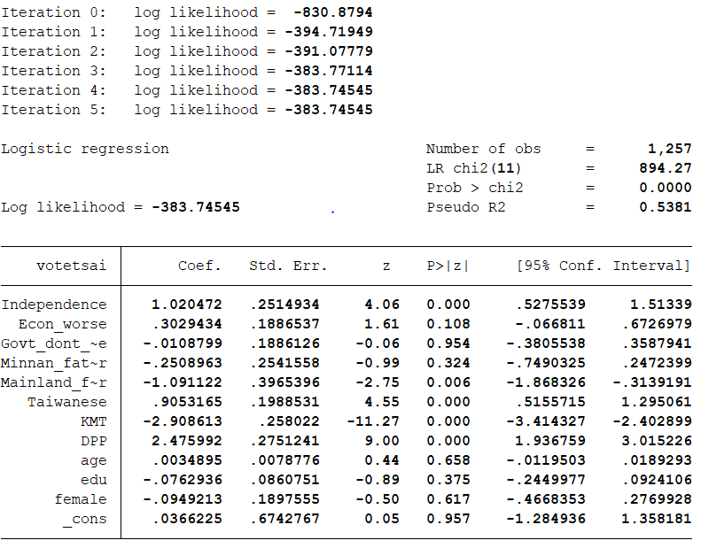